# 02_Graphs_Types

## Типи графів.

**Null граф**, якщо у графі немає ребер. Вершини є ізольованими.

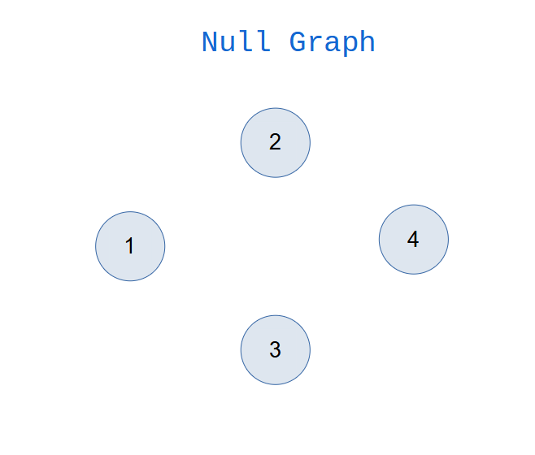

**Тривіальний граф** (Trivial Graph) має лише одну вершину. Є найменшим можливим графом.

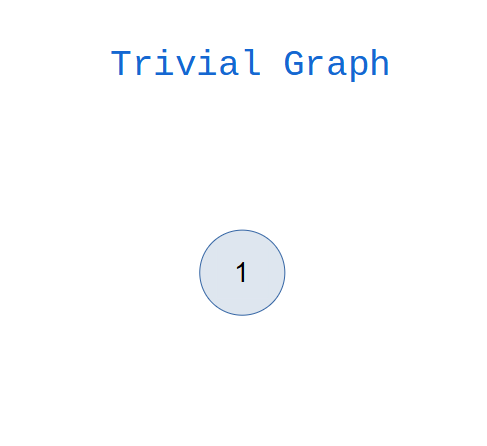

**Неорієнтований граф** (Undirected Graph). Граф, ребра якого немають напряму. Вузли є невпорядкованими парами у визначенні кожного ребра.

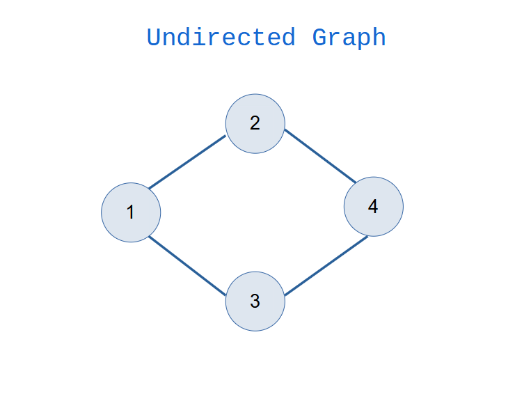

**Орієнтований/направлений граф** (Directed Graph). Граф, у якому ребро має напрямок. Ребро `(u, v)` не обов’язково означає, що також існує ребро `(v, u)`. Ребра в такому графі представлені стрілками, щоб показати напрямок ребра. Вузли є впорядкованими парами у визначенні кожного ребра.

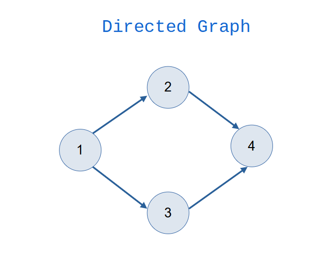

**Зв’язаний граф** (Connected Graph). Граф, у якому з одного вузла можемо відвідати будь-який інший вузол у графі.

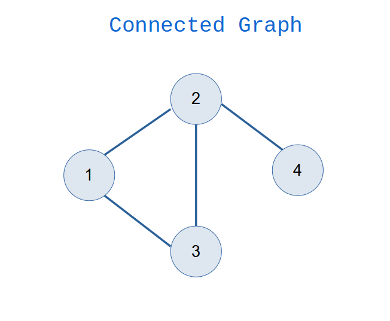

**Незв’язаний граф** (Disconnected Graph). Граф, у якому хоча б один вузол недоступний з іншого вузла.

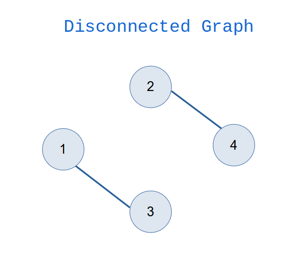

**Граф циклу** (Cycle Graph). Граф, який сам собою є циклом. Ступінь кожної вершини дорівнює 2.

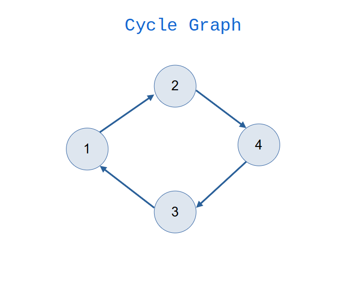

**Циклічний граф** (Cyclic Graph). Граф, який містить хоча б один цикл.

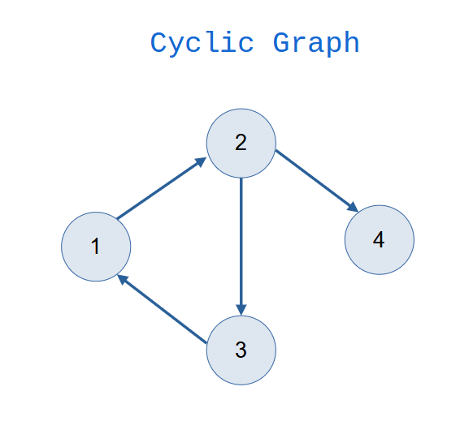

**Направлений ациклічний граф** (Directed Acyclic Graph). Направлений граф, який не містить циклів.

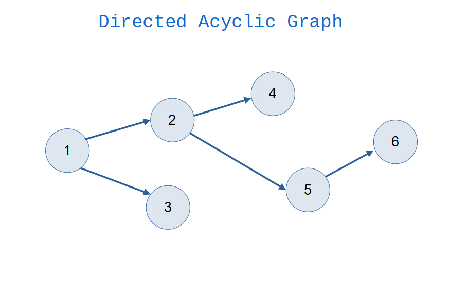

**Зважений граф** (Weighted Graph). Граф, в якому ребра вже вказані з відповідним вагою. Вага - значення, що асоціюється з поданням реальних сутностей, таких як вартість, відстань та кількість. Зважені графи можуть бути орієнтованими або неорієнтованими графами.

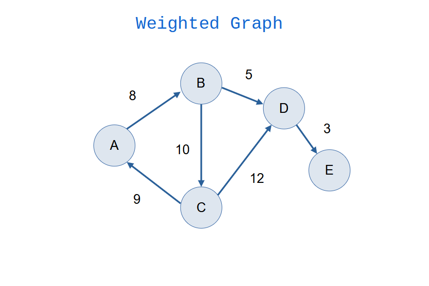

**Дерево** (Tree) – тип графа, але з деякими додатковими правилами. Дерево `T` з `n` вершинами має `n-1` ребер. Підграф `T` зв’язаного графа `G(V,E)` називається остовним (spanning) деревом, якщо `T` є деревом та містить усі вершини графа `G`. Якщо вершина пропущена, то це не остовне дерево. Остовне дерево - це підграф неорієнтованого зв’язаного графа, що включає всі вершини графа з мінімально можливим числом ребер. Дерево – це зв’язаний ациклічний граф.

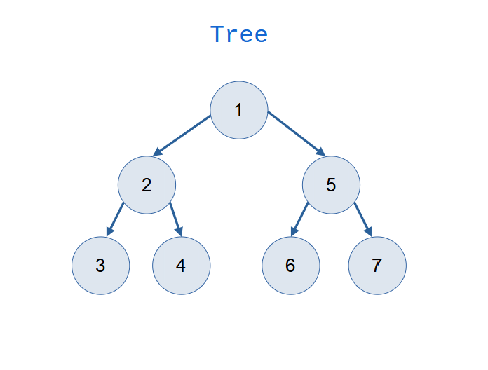